# Cap Bussiness

A visual and analytic analysis of cost and profits.

Given the following parameters:

- Considerando o Euro a 6.50
- Custo de Produção = 35 Reais ~ 5.38
- Preço de Venda EU = 21 Euros
- Preço de Venda BR = 75 Reais
- Preço de Venda Internt (WR) = 21 Euros
- Num de Bones vendidos:
  - Brasil = 50
  - EU = 50
  - WR = 20

## Cost Production

Breaking down cost production for a single unit of cap.

[interactive chart not shown]

## Revenue

Having a look closely to Revenue regarding different markets

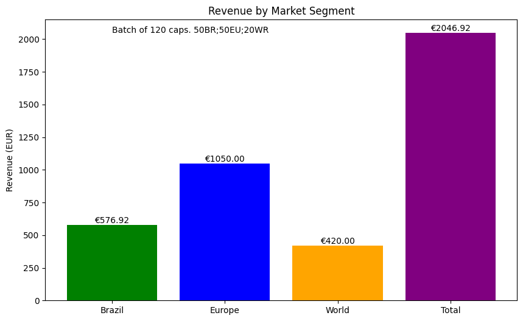

### Profit

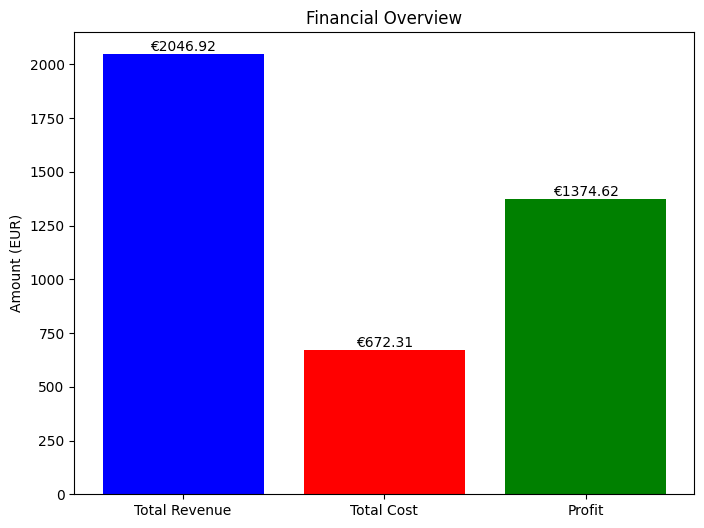

### General Panoram of Sales Distribution

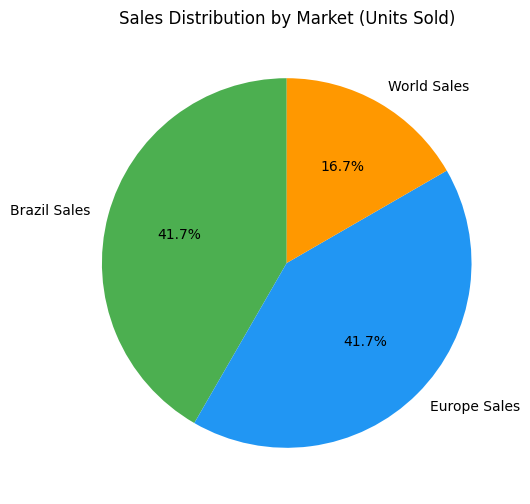

## Financial Overview

[interactive chart not shown]

## Distribution Amount of Sales over different Scenarios

Takes into consideration different scenarios for cap market

[interactive chart not shown]

## Individual Profit

### Conceptual Comission

[interactive chart not shown]

### Comparison EU vc BR sell for selling comission

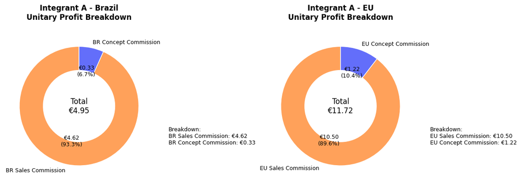

### EU sell

[interactive chart not shown]

### BR Sell

[interactive chart not shown]

```
Ou seja, alguem vendendo 20 bones no Brasil, com comissao de conceito, e supondo que todos os outros bones sejam vendidos, teria um lucro de 1605.62 reais
```

## Exploring Future Range of Sell Price

### Elasticity Scenarios

- Key findings
- Each €1 increase → +€50 revenue (with same sales volume) (EU MARKET)
- Each R$1 increase → ≈€7.69 revenue increase

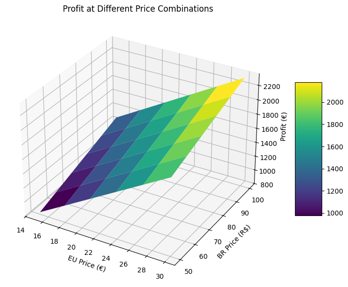

### Break-Even Analysis

A break-even price is the amount of money, or change in value, for which an asset must be sold to cover the costs of acquiring and owning it

It can also refer to the amount of money for which a product or service must be sold to cover the costs of manufacturing or providing it.

Key Findings:

- Break-even price if only selling in EU: €15.46 per cap
- Break-even price if only selling in Brazil: R$100.52 per cap
- Mixed market break-even: €6.44 (just covers unit cost)

[interactive chart not shown]

- At current EU price (€21), you need to sell ~37 caps to break even
- At R$75 (≈€11.54), you need ~ 67 Brazil sales to break even
- The red line shows production capacity - prices below €6.44 mean you can't break even even if selling all 120 caps

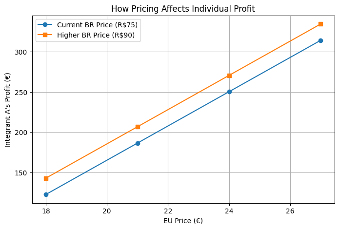

### Key Findings:

Actionable Recommendations:

- Test Higher EU Prices First
- Try increasing EU prices to €23-25 (9-19% increase) where demand is likely less sensitive

Brazil Market Optimization:

- Current R$75 is relatively low compared to break-even
- onsider bundling or value-add to justify R$85-90 prices

Team Incentives Alignment

- Higher prices shift profit balance toward sales commissions
- Consider adjusting commission ratios if pursuing significant price increases